# 資料探勘101

曾意儒 Yi-Ju Tseng

## 大綱

- 什麼是資料探勘
- Regression 迴歸
- Decision Trees 決策樹
- 模型驗證
- 效能指標

### 什麼是資料探勘

建立從**輸入資料**學習新資訊，變成智慧的**演算法**或**資料模式**，用來**預測事件**或**協助決策**

- 用人工智慧、機器學習、統計學等方法
- 在相對較大型的資料集中發現模式的計算過程
- 當資料太`少`或`太髒`的時候，資料探勘的效力會被影響。

### 資料探勘條件

資料探勘要派上用場，必須有以下條件：

- 有一些模式/模型可`學`
- 很難定義這些模式/模型
- 有資料可`學`這些模式/模型

### 資料探勘可應用在

- 天氣預測
- 搜尋建議、購物建議
- 股市預測
- 臉部辨識、指紋辨識
- 垃圾郵件標記
- 尿布啤酒

### 資料探勘的分類

- **監督式**學習與**非監督式**學習
- 監督式學習的特點是訓練資料中有**正確答案**，由輸入物件和預期輸出所組成，而演算法可以由訓練資料中學到或建立一個模式，並依此模式推測新的實例
- 非監督式學習則不用提供**正確答案**，也就是不需要人力來輸入標籤，單純利用訓練資料的特性，將資料分群分組。

### 資料探勘的分類

- Supervised learning 監督式學習
  - Regression 迴歸：真實的'值'（股票、氣溫）
  - Classification 分類：分兩類（P/N, Yes/No, M/F, Sick/Not sick）/分多類 (A/B/C/D)
- Unsupervised learning 非監督式學習
  - Clustering 分群
  - Association Rules 關聯式規則

### 監督式學習

在**監督式**學習中常見的資料探勘演算法如下：

- Linear Regression 線性迴歸
- Logistic Regression 羅吉斯迴歸、邏輯迴歸
- Support Vector Machines 支持向量機
- Decision Trees 決策樹
- K-Nearest Neighbor
- Neural Networks 神經網路
- Deep Learning 深度學習

### 非監督式學習

在**非監督式**學習中常見的資料探勘演算法如下：

- Hierarchical clustering 階層式分群
- K-means clustering
- Neural Networks 神經網路
- Deep Learning 深度學習

### Regression 迴歸

- 用在了解兩個或多個變數間`是否相關`、`相關方向與強度`
- 建立`數學模型`以便觀察特定變數來預測研究者感興趣的變數

常見的迴歸分析演算法包括：

- Linear Regression 線性迴歸
- Logistic Regression 羅吉斯迴歸、邏輯迴歸

### Linear Regression 線性迴歸

- 嘗試將Linear Regression 線性迴歸用在NBA的資料
- 做NBA`得分`與`上場分鐘數`的線性迴歸觀察

```r
options(digits = 3)
#讀入SportsAnalytics package
library(SportsAnalytics)
#擷取2015-2016年球季球員資料
NBA1516<-fetch_NBAPlayerStatistics("15-16")
```

### 迴歸線作圖

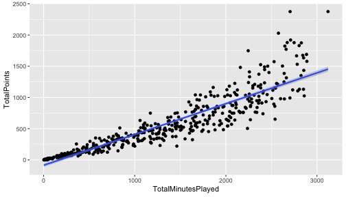

```r
library(ggplot2)
ggplot(NBA1516,
       aes(x=TotalMinutesPlayed,
           y=TotalPoints))+
  geom_point()+
  geom_smooth(method = "glm")
```

### lm()

- 最基本的簡單線性迴歸分析為`lm()`
- `lm(formula,data=資料名稱)`，搭配formula使用
- formula的撰寫方法為：依變項~自變項1＋自變項2＋….

```r
lm(TotalPoints~TotalMinutesPlayed,
   data =NBA1516)
```

```
Call:
lm(formula = TotalPoints ~ TotalMinutesPlayed, data = NBA1516)

Coefficients:
       (Intercept)  TotalMinutesPlayed
           -85.907               0.493
```

TotalPoints = `0.4931` * TotalMinutesPlayed `-85.9071`

### glm()

- 更被廣泛使用的是廣義線性迴歸模型generalized linear models (glm)，`glm()`
- 使用方法與`lm()`類似
- 包括線性迴歸模型和邏輯迴歸模型
- 如果需要修改預設模型，可設定family參數：
  - `family="gaussian"` 線性模型模型
  - `family="binomial"` 邏輯迴歸模型
  - `family="poisson"` 卜瓦松迴歸模型

### Gaussian distribution

Gaussian distribution高斯函數是`常態分布`的密度函數

[figure not shown]

### Binomial distribution

Binomial distribution二項分布是`n個獨立的是/非試驗中成功的次數`的離散機率分布

[figure not shown]

### Poisson distribution

Poisson distribution`次數`分佈：

- 某一服務設施在一定時間內受到的服務請求的次數
- 公車站的候客人數
- 自然災害發生的次數

[figure not shown]

### 廣義線性迴歸與NBA

分析`得分`與`上場分鐘數`和`兩分球出手數`的關係範例

```r
# e+01: 10^1 / e-04: 10^(-4)
fit<-glm(TotalPoints ~
      TotalMinutesPlayed+FieldGoalsAttempted,
    data =NBA1516)
summary(fit)$coefficients
```

|  | Estimate | Std. Error | t value | Pr(>\|t\|) |
| --- | --- | --- | --- | --- |
| (Intercept) | -17.99 | 5.660 | -3.178 | 0.002 |
| TotalMinutesPlayed | 0.00 | 0.009 | -0.025 | 0.980 |
| FieldGoalsAttempted | 1.26 | 0.022 | 56.467 | 0.000 |

TotalPoints = `-0.0002347` * TotalMinutesPlayed + `1.255794` *FieldGoalsAttempted `-17.99`

### 廣義線性迴歸與NBA

如需使用多變量線性迴歸來分析`得分`與`上場分鐘數`和`兩分球出手數`和`守備位置`的關係，可修改formula

```r
fit<-glm(TotalPoints~
         TotalMinutesPlayed+
         FieldGoalsAttempted+Position,
    data =NBA1516)
summary(fit)$coefficients
```

|  | Estimate | Std. Error | t value | Pr(>\|t\|) |
| --- | --- | --- | --- | --- |
| (Intercept) | 22.852 | 9.015 | 2.535 | 0.012 |
| TotalMinutesPlayed | -0.007 | 0.009 | -0.711 | 0.478 |
| FieldGoalsAttempted | 1.276 | 0.022 | 58.932 | 0.000 |
| PositionPF | -39.416 | 9.937 | -3.967 | 0.000 |
| PositionPG | -65.035 | 10.269 | -6.333 | 0.000 |
| PositionSF | -38.522 | 10.488 | -3.673 | 0.000 |
| PositionSG | -52.175 | 9.985 | -5.225 | 0.000 |

### 虛擬變項 Dummy Variable

- `守備位置`的變項被轉為**虛擬變項 Dummy Variable**
- PositionPF、PositionPG、PositionSF、PositionSG
- 如果是控球後衛（PG），會得到：
  - PositionPF=0
  - PositionPG=1
  - PositionSF=0
  - PositionSG=0

### 中鋒去哪了？

- 中鋒被當作基準項
- 當守備位置是中鋒( C )時，會得到：
  - PositionPF=0
  - PositionPG=0
  - PositionSF=0
  - PositionSG=0

### 線性迴歸練習

- 用[BostonHousing](https://archive.ics.uci.edu/ml/datasets/Housing)資料
  - install.packages(“mlbench”)
  - library(mlbench)
  - data(BostonHousing)
- 使用crim、tax、dis欄位預測medv(Median value of owner-occupied homes in $1000's)
  - glm()廣義線性迴歸

### 線性迴歸總結

總結以上，多變量線性迴歸分析有下列特色：

- 假設：各變數相互獨立！
- 若自變項X是類別變項，需要建立`虛擬變項`
- 在R裡，`類別變項`請記得轉成factor，R會自動建立`虛擬變項`
- 用在`依變數為連續變數`，`自變數為連續變數或虛擬變數`的場合

### Logistic Regression 羅吉斯迴歸

常用在`依變數為二元變數（非0即1）`的場合，如：

- 生病/沒生病
- 錄取/不錄取
- `family="binomial"` 邏輯迴歸模型

### 分析為什麼錄取/不錄取？

```r
mydata <- read.csv("https://raw.githubusercontent.com/CGUIM-BigDataAnalysis/BigDataCGUIM/master/binary.csv")
```

```r
# GRE:某考試成績, GPA:在校平均成績, rank:學校聲望
head(mydata)
```

| admit | gre | gpa | rank |
| --- | --- | --- | --- |
| 0 | 380 | 3.61 | 3 |
| 1 | 660 | 3.67 | 3 |
| 1 | 800 | 4.00 | 1 |
| 1 | 640 | 3.19 | 4 |
| 0 | 520 | 2.93 | 4 |
| 1 | 760 | 3.00 | 2 |

### 分析為什麼錄取/不錄取？

```r
mydata$rank <- factor(mydata$rank)
mylogit <- glm(admit ~ gre + gpa + rank,
               data = mydata,
               family = "binomial")
sum<-summary(mylogit)
```

```r
sum$coefficients
```

|  | Estimate | Std. Error | z value | Pr(>\|z\|) |
| --- | --- | --- | --- | --- |
| (Intercept) | -3.990 | 1.140 | -3.50 | 0.000 |
| gre | 0.002 | 0.001 | 2.07 | 0.038 |
| gpa | 0.804 | 0.332 | 2.42 | 0.015 |
| rank2 | -0.675 | 0.316 | -2.13 | 0.033 |
| rank3 | -1.340 | 0.345 | -3.88 | 0.000 |
| rank4 | -1.551 | 0.418 | -3.71 | 0.000 |

### 羅吉斯迴歸練習

- 用[PimaIndiansDiabetes](https://archive.ics.uci.edu/ml/datasets/Pima+Indians+Diabetes)資料
  - install.packages(“mlbench”)
  - library(mlbench)
  - data(PimaIndiansDiabetes)
- 使用pregnant、glucose、triceps、mass欄位預測diabetes
  - glm()廣義線性迴歸
  - family = “binomial”

### 最佳模型篩選

到底該用哪個模型來預測，會得到最準確的結果？在迴歸模型中，常用的判斷準則包括：

- Akaike’s Information Criterion (AIC)
- Bayesian Information Criterion (BIC)

### AIC

AIC和BIC都是數值越小越好，以下建立三個模型，並比較其AIC

```r
OneVar<-glm(TotalPoints~
              TotalMinutesPlayed,
            data =NBA1516)
TwoVar<-glm(TotalPoints~
              TotalMinutesPlayed+
              FieldGoalsAttempted,
            data =NBA1516)
ThreeVar<-glm(TotalPoints~
                TotalMinutesPlayed+
                FieldGoalsAttempted+Position,
              data =NBA1516)
```

### AIC

```r
c(OneVar$aic,TwoVar$aic,ThreeVar$aic)
```

```
[1] 6339 5367 5322
```

### 所有參數都有用嗎？

- 在建立迴歸模型時，常會遇到的問題：到底該放多少參數？
- 所有參數都有用嗎？
- 藉由觀察coefficients來判斷參數在模型中的"實用程度“

```r
sum2<-summary(TwoVar)
sum2$coefficients
```

|  | Estimate | Std. Error | t value | Pr(>\|t\|) |
| --- | --- | --- | --- | --- |
| (Intercept) | -17.99 | 5.660 | -3.178 | 0.002 |
| TotalMinutesPlayed | 0.00 | 0.009 | -0.025 | 0.980 |
| FieldGoalsAttempted | 1.26 | 0.022 | 56.467 | 0.000 |

### 所有參數都有用嗎？

```r
sum3<-summary(ThreeVar)
sum3$coefficients
```

|  | Estimate | Std. Error | t value | Pr(>\|t\|) |
| --- | --- | --- | --- | --- |
| (Intercept) | 22.852 | 9.015 | 2.535 | 0.012 |
| TotalMinutesPlayed | -0.007 | 0.009 | -0.711 | 0.478 |
| FieldGoalsAttempted | 1.276 | 0.022 | 58.932 | 0.000 |
| PositionPF | -39.416 | 9.937 | -3.967 | 0.000 |
| PositionPG | -65.035 | 10.269 | -6.333 | 0.000 |
| PositionSF | -38.522 | 10.488 | -3.673 | 0.000 |
| PositionSG | -52.175 | 9.985 | -5.225 | 0.000 |

### Decision Trees 決策樹

- 在`樹狀目錄`中建立一系列分割，以建立模型
- 這些分割會表示成`「節點」(Node)`
- 每次發現輸入資料行與可預測資料行有明顯地相互關聯時，此演算法就會在模型中加入一個`節點`
- 演算法決定分岔的方式不同

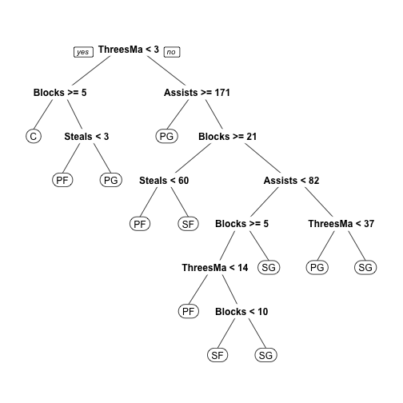

### Classification And Regression Tree (CART)

- 常見的Classification And Regression Tree (CART)
- 使用前須先安裝`rpart` packages

```r
install.packages("rpart")
```

### CART

```r
library(rpart)
DT<-rpart(Position~
            Blocks+ThreesMade+Assists+Steals,
          data=NBA1516)
DT
```

```
n=475 (1 observation deleted due to missingness)

node), split, n, loss, yval, (yprob)
      * denotes terminal node

  1) root 475 364 PF (0.15 0.23 0.21 0.18 0.23)
    2) ThreesMade< 2.5 132  74 C (0.44 0.35 0.098 0.053 0.061)
      4) Blocks>=4.5 89  37 C (0.58 0.38 0.011 0.011 0.011) *
      5) Blocks< 4.5 43  31 PF (0.14 0.28 0.28 0.14 0.16)
       10) Steals< 2.5 29  19 PF (0.17 0.34 0.14 0.21 0.14) *
       11) Steals>=2.5 14   6 PG (0.071 0.14 0.57 0 0.21) *
    3) ThreesMade>=2.5 343 242 SG (0.035 0.19 0.25 0.23 0.29)
      6) Assists>=170 96  39 PG (0.031 0.052 0.59 0.15 0.18) *
      7) Assists< 170 247 163 SG (0.036 0.24 0.12 0.26 0.34)
       14) Blocks>=20.5 80  42 PF (0.062 0.48 0 0.26 0.2)
         28) Steals< 59.5 58  21 PF (0.069 0.64 0 0.14 0.16) *
         29) Steals>=59.5 22   9 SF (0.045 0.045 0 0.59 0.32) *
       15) Blocks< 20.5 167  99 SG (0.024 0.13 0.17 0.26 0.41)
         30) Assists< 81.5 110  68 SG (0.027 0.18 0.091 0.32 0.38)
           60) Blocks>=4.5 63  39 SF (0.032 0.29 0.016 0.38 0.29)
            120) ThreesMade< 13.5 19   9 PF (0.11 0.53 0 0.26 0.11) *
            121) ThreesMade>=13.5 44  25 SF (0 0.18 0.023 0.43 0.36)
              242) Blocks< 9.5 17   7 SF (0 0.18 0.059 0.59 0.18) *
              243) Blocks>=9.5 27  14 SG (0 0.19 0 0.33 0.48) *
           61) Blocks< 4.5 47  23 SG (0.021 0.043 0.19 0.23 0.51) *
         31) Assists>=81.5 57  31 SG (0.018 0.035 0.33 0.16 0.46)
           62) ThreesMade< 37 17   5 PG (0 0.12 0.71 0.059 0.12) *
           63) ThreesMade>=37 40  16 SG (0.025 0 0.17 0.2 0.6) *
```

### 決策樹圖

改用`rpart.plot` package 裡面的`prp()`

```r
#第一次使用前須先安裝
install.packages("rpart.plot")
```

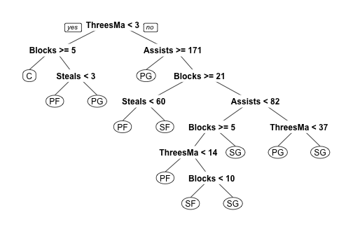

```r
library(rpart.plot)
prp(DT)
```

### 決策樹 節點

決策樹演算法決定`節點`的方式如下：

- Gini impurity
- Information gain
- Variance reduction

細節可參考[維基百科](https://en.wikipedia.org/wiki/Decision_tree_learning)

### 決策樹 練習

- 用[PimaIndiansDiabetes](https://archive.ics.uci.edu/ml/datasets/Pima+Indians+Diabetes)資料
  - install.packages(“mlbench”)
  - library(mlbench)
  - data(PimaIndiansDiabetes)
- 使用所有欄位預測diabetes
  - diabetes~.
- 使用rpart.plot套件畫出決策樹
  - prp()

### 模型驗證

- 在完成模型訓練後，為了驗證模型訓練的好不好，需要用一組**獨立**的測試資料，來做模型的驗證
- 在訓練模型前，必須特別留意是否有保留一份**獨立的資料**，並確保在訓練模型時都不用到此獨立資料集。

因此，資料集可分為以下兩種：

- **訓練組** Training set, Development set: 讓演算法`學`到`知識`
- **測試組** Test set, Validation set: 驗證`學`的怎麼樣
- Training set和Test set通常會比例分配
  - 如2/3的資料設為`Training set`
  - 剩下的1/3做驗證`Test set`

### 模型驗證 （監督式學習）

可以注意到綠色箭頭的資料集在訓練過程中從未被使用。

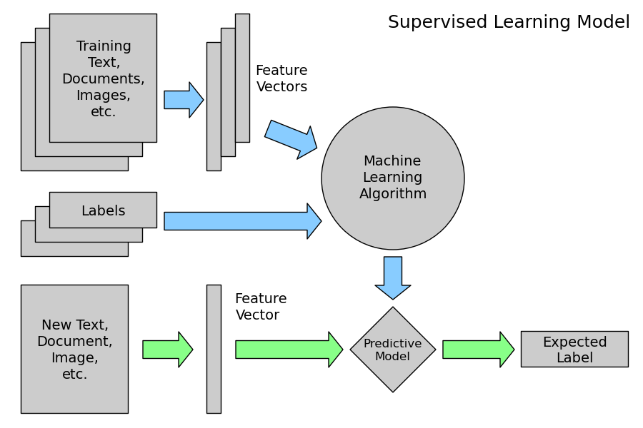

### 模型驗證

- 以Training set來`選看起來最好的模型`
- 用Test set來`驗證模型是不是真的很好`
- 想像…..訓練出來題庫答得好的學生，寫到新題目不一定會寫！？
- 訓練模型時，只能看Training set，用Training set來選一個最好的模型
- 訓練模型時，不能偷看Test set，才是真正的驗證

### Regression 迴歸驗證

以NBA資料為例，首先先將資料讀入

```r
#讀入SportsAnalytics package
if (!require('SportsAnalytics')){
    install.packages("SportsAnalytics")
    library(SportsAnalytics)
}
#擷取2015-2016年球季球員資料
NBA1516<-fetch_NBAPlayerStatistics("15-16")
#只保留完整的資料
NBA1516<-NBA1516[complete.cases(NBA1516),]
```

### Regression 迴歸驗證：資料分組

為分出訓練組與測試組，需使用隨機抽樣的方式

```r
# 從1到10，隨機取三個數字
sample(1:10,3)
```

```
[1] 1 7 5
```

```r
#從第一列到最後一列，隨機取1/3列數
sample(1:nrow(NBA1516),nrow(NBA1516)/3)
```

```
  [1] 111  44 288 402 249 262 108 201 211 322 368 282 169 418 460 452 177
 [18] 405 200 208 284 297 106 468  13  51 131 179  45 386 281 194 150   3
 [35] 258 274 253 273 222 463 369 146   4  12 132 349  27 472  68 124 384
 [52]  99  31 135 171 209  92 242 196  23 421 291 358 255  90 107 325 425
 [69]  58  66 355 436 362 361 343 145 474 346  73  91 445 172 166  70 161
 [86] 237 115 263 221 337 372 100 214 225 134 394 290  34 235  84 430 470
[103] 250 348 157 432 264 277  15 431 251  10 286  65 120 354 236 298 313
[120] 296 473 441 471 331  16 193 130 419 413 461 401 272 167 443 270 244
[137] 467 203 341 304 190 335 396 215   7 142  64 328 109 148 458 256 340
[154] 389 457 390 378  72
```

### Regression 迴歸驗證：資料分組

使用隨機抽樣法，選出1/3的元素位置，把NBA的資料分成Training 和 Test set

```r
#新增一個參數紀錄分組
NBA1516$Test<-F
#隨機取1/3當Test set
testIndex<-
    sample(1:nrow(NBA1516),nrow(NBA1516)/3)
NBA1516[testIndex,]$Test<-T
trainData<-NBA1516[NBA1516$Test==F,]
testData<-NBA1516[NBA1516$Test==T,]
# Training set : Test set球員數
c(sum(NBA1516$Test==F),sum(NBA1516$Test==T))
```

```
[1] 317 158
```

### Regression 迴歸驗證：模型訓練

並用訓練組的資料（NBA1516$Test==F），訓練一個多變數線性迴歸模型

```r
fit<-glm(TotalPoints~TotalMinutesPlayed+
            FieldGoalsAttempted+Position+
            ThreesAttempted+
            FreeThrowsAttempted,
              data =trainData)
summary(fit)$coefficients
```

|  | Estimate | Std. Error | t value | Pr(>\|t\|) |
| --- | --- | --- | --- | --- |
| (Intercept) | 7.929 | 7.756 | 1.022 | 0.307 |
| TotalMinutesPlayed | 0.007 | 0.008 | 0.988 | 0.324 |
| FieldGoalsAttempted | 1.003 | 0.024 | 41.658 | 0.000 |
| PositionPF | -14.882 | 8.374 | -1.777 | 0.077 |
| PositionPG | -40.421 | 9.076 | -4.454 | 0.000 |
| PositionSF | -11.640 | 9.204 | -1.265 | 0.207 |
| PositionSG | -30.622 | 9.013 | -3.398 | 0.001 |
| ThreesAttempted | 0.098 | 0.033 | 2.999 | 0.003 |
| FreeThrowsAttempted | 0.684 | 0.042 | 16.316 | 0.000 |

### Regression 迴歸驗證：逐步選擇模型

逐步選擇模型 stepwise 雙向學習：參數加加減減

```r
##根據AIC做逐步選擇, 雙向direction = "both"
library(MASS)
finalModel_Both<-
    stepAIC(fit,direction = "both",
            trace=FALSE)
summary(finalModel_Both)$coefficients
```

|  | Estimate | Std. Error | t value | Pr(>\|t\|) |
| --- | --- | --- | --- | --- |
| (Intercept) | 10.973 | 7.117 | 1.54 | 0.124 |
| FieldGoalsAttempted | 1.018 | 0.019 | 54.29 | 0.000 |
| PositionPF | -16.019 | 8.294 | -1.93 | 0.054 |
| PositionPG | -41.715 | 8.980 | -4.64 | 0.000 |
| PositionSF | -12.509 | 9.162 | -1.36 | 0.173 |
| PositionSG | -31.657 | 8.951 | -3.54 | 0.000 |
| ThreesAttempted | 0.102 | 0.032 | 3.16 | 0.002 |
| FreeThrowsAttempted | 0.685 | 0.042 | 16.35 | 0.000 |

### Regression 迴歸驗證：模型驗證

用Test set來評估模型，使用predict函數

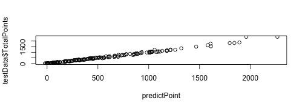

```r
predictPoint<-predict(finalModel_Both,
                      newdata = testData)
plot(x=predictPoint,y=testData$TotalPoints)
```

```r
cor(x=predictPoint,y=testData$TotalPoints)
```

```
[1] 0.995
```

### 邏輯迴歸驗證

- 先把[入學資料](https://raw.githubusercontent.com/CGUIM-BigDataAnalysis/BigDataCGUIM/master/binary.csv)載入

```r
mydata <- read.csv("https://raw.githubusercontent.com/CGUIM-BigDataAnalysis/BigDataCGUIM/master/binary.csv")
# 類別變項轉為factor
#mydata$admit <- factor(mydata$admit,levels = c(0,1))
mydata$rank <- factor(mydata$rank)
```

### 邏輯迴歸驗證

- 把[入學資料](https://raw.githubusercontent.com/CGUIM-BigDataAnalysis/BigDataCGUIM/master/binary.csv)分成Training 和 Test set

```r
mydata$Test<-F #新增一個參數紀錄分組
#隨機取1/3當Test set
testIndex<-sample(1:nrow(mydata),nrow(mydata)/3)
mydata[testIndex,]$Test<-T
testData<-mydata[mydata$Test==T,]
trainData<-mydata[mydata$Test==F,]
```

### 邏輯迴歸驗證：訓練

```r
# GRE, GPA:在校成績, rank:學校聲望
mylogit <- glm(admit ~ gre + gpa + rank,
               data = trainData,
               family = "binomial")
finalFit<-stepAIC(mylogit,direction = "both",
                  trace=FALSE) # 雙向逐步
```

```r
summary(finalFit)$coefficients
```

|  | Estimate | Std. Error | z value | Pr(>\|z\|) |
| --- | --- | --- | --- | --- |
| (Intercept) | -2.226 | 0.869 | -2.56 | 0.010 |
| gre | 0.004 | 0.001 | 2.93 | 0.003 |
| rank2 | -0.588 | 0.387 | -1.52 | 0.129 |
| rank3 | -1.130 | 0.410 | -2.75 | 0.006 |
| rank4 | -1.407 | 0.514 | -2.74 | 0.006 |

### 邏輯迴歸驗證：驗證

用預測組預測新學生可不可以錄取，並驗證答案

```r
#結果為每個人被錄取的機率
AdmitProb<-predict(finalFit, # 模型
                   newdata = testData,
                   type="response")
table(AdmitProb>0.2,testData$admit)
```

```
         0  1
  FALSE 25  3
  TRUE  67 38
```

### 效能指標

當答案是二元時：效能指標

- Sensitivity 敏感性
- Specificity 特異性
- Positive Predictive Value (PPV) 陽性預測值
- Negative Predictive Value (NPV) 陰性預測值

### 效能指標名詞解釋

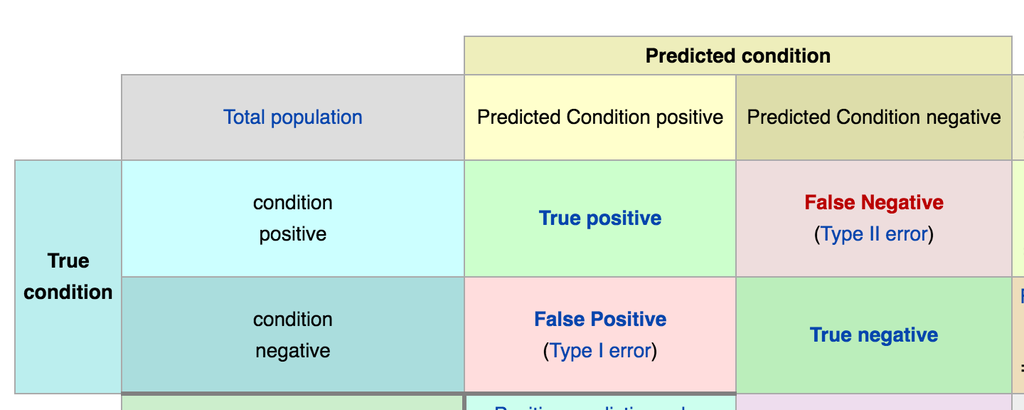

- TP: 有病且預測也有病
- TN: 沒病且預測也沒病
- FP: 沒病但是預測有病
- FN: 有病但預測沒病

### 效能指標名詞解釋

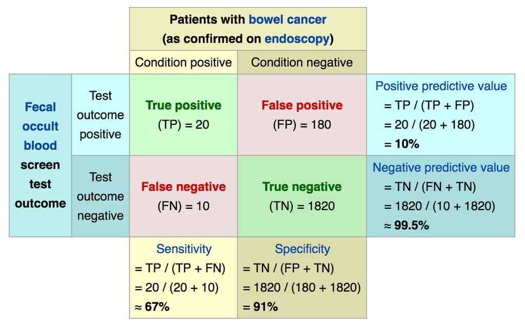

### 效能指標公式

當答案是二元時：效能指標公式

- Sensitivity 敏感性：所有`真的有病`的人，被`預測有病`的比例
- Specificity 特異性：所有`真的沒病`的人，被`預測沒病`的比例
- Positive Predictive Value (PPV) 陽性預測值：所有被`預測有病`的人，`真的有病`的比例
- Negative Predictive Value (NPV) 陰性預測值：所有被`預測沒病`的人，`真的沒病`的比例

### 效能指標

```r
# 回想一下剛剛的驗證結果
table(AdmitProb>0.2,testData$admit)
```

```
         0  1
  FALSE 25  3
  TRUE  67 38
```

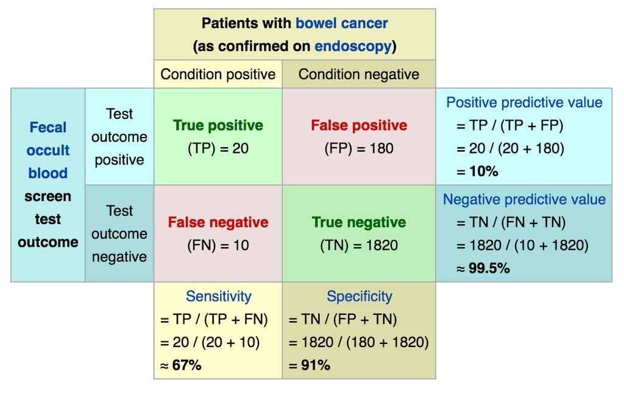

### 效能指標

計算預測效能參數

```r
#每個人被錄取的機率
AdmitAns<-factor(ifelse(AdmitProb>0.2,1,0),
                 levels=c(1,0))
GoldAns<-factor(testData$admit,
                levels=c(1,0))
table(AdmitAns,GoldAns)
```

```
        GoldAns
AdmitAns  1  0
       1 38 67
       0  3 25
```

### 效能指標

計算預測效能參數

```r
# install.packages("caret")
library(caret)  #計算參數的packages
sensitivity(AdmitAns,GoldAns)
```

```
[1] 0.927
```

```r
specificity(AdmitAns,GoldAns)
```

```
[1] 0.272
```